# COBP_IPM

Alice Stears

2/2/2022

## Background

*Oenothera coloradensis* is a monocarpic perennial herb that occurs in riparian and wetland habitats in southeast Wyoming, southwest Nebraska, and northern Colorado. It was listed as “threatened” under the Endangered Species Act until December, 2019. It was originally listed because it is naturally rare, and even though it’s ESA designation has since been removed, this species is still very uncommon. One chapter of my dissertation is using demographic methods to investigate the mechanisms that allow populations of this rare species to persist. I am building an integral projection model (IPM) for this species, and can use results from this model to test for the existence of several different persistence mechanisms.

I have three consecutive years of pre-reproductive census data for this species, which includes survival status, size (longest leaf), reproductive status, and reproductive output for each year. I also have counts of ‘seedlings’ in each year (individuals less than 3 cm in leaf length), and estimates of seed germination rate and seed vitality rate. This updated IPM has only one discrete stage for seeds, and incorporates the seedlings into the continuous plant data. While we only have counts of seedlings in each quadrat and year, we know that they were less than three cm in longest leaf size. I added a row to the continuous dataset for each seedling, and randomly assigned it a size_t by sampling from a uniform distribution between 0.1 and 3. Additionally, because we know how how many individuals were ‘new recruits’ to the >3 cm size class in year t+1, we can estimate the survival probability of seedlings in year t. For the seedlings that survived to the next year, I randomly assigned them a ‘new recruit’ from the next year so each surviving seedling has data for size_t+1.

I fit an IPM using this new dataset, the details of which are below:

### *Oenothera coloradensis* life-cycle diagram

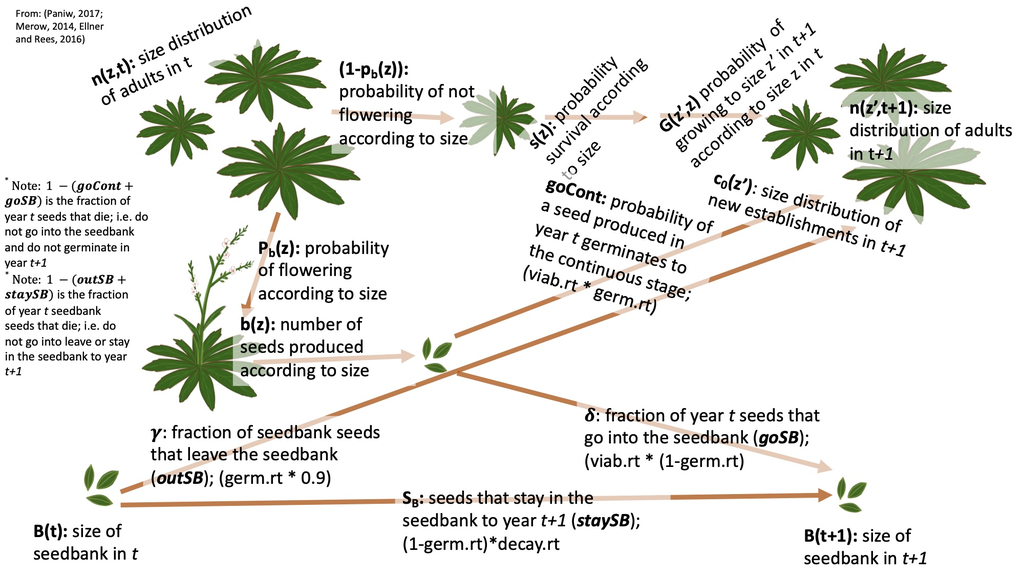

Figure of the O. coloradensis life-cycle, with transitions labeled

### Functions in the IPM kernel

**Distribution of size of individuals in year *t+1* (continuous stage):**
New recruits from the seedling stage + growth and survival kernel
$$n(z',t+1) = \int_{L}^{U}(1-P_b(z))s(z)G(z',z)n(z,t)dz + goCont\int_{L}^{U}P_b(z)b(z)c_o(z')n(z,t)dz + B(t) * outSB *c_o(z')$$

**Seedbank (discrete stage):**
seeds that stay in the seedbank + seeds that are added to the seedbank by seed production from adult plants
$$B(t+1) = B(t)staySB+goSB\int_{L}^{U}P_b(z)b(z)n(z,t)dz$$
QUESTIONS:
1. Is this math a correct interpretation of the life cycle shown above?

### Make vital rate models

**Load census data**

```r
# load continuous stage data
# replace this with the location of 'COBP_long_CURRENT' on your machine
fileName_1 <- "../../Processed_Data/allDat_plus_contSeedlings.csv"

dat <- read.csv(fileName_1)
```

**Survival ($s(z)$)**

```r
# subset the data to exclude flowering individuals
 survDat_N <- dat[dat$flowering==0 | is.na(dat$flowering),]

# logistic glm with log-transformed size_t
 survMod_N <- glm(survives_tplus1 ~ log_LL_t + N_all , data = survDat_N, family = binomial)
 summary(survMod_N)
```

```
##
## Call:
## glm(formula = survives_tplus1 ~ log_LL_t + N_all, family = binomial,
##     data = survDat_N)
##
## Deviance Residuals:
##     Min       1Q   Median       3Q      Max
## -1.6264  -1.2072   0.8641   1.0627   1.7038
##
## Coefficients:
##               Estimate Std. Error z value Pr(>|z|)
## (Intercept) -0.3600359  0.0555230  -6.484 8.91e-11 ***
## log_LL_t     0.3809705  0.0233030  16.349  < 2e-16 ***
## N_all        0.0003646  0.0001025   3.558 0.000374 ***
## ---
## Signif. codes:  0 '***' 0.001 '**' 0.01 '*' 0.05 '.' 0.1 ' ' 1
##
## (Dispersion parameter for binomial family taken to be 1)
##
##     Null deviance: 9130.0  on 6624  degrees of freedom
## Residual deviance: 8843.6  on 6622  degrees of freedom
##   (1543 observations deleted due to missingness)
## AIC: 8849.6
##
## Number of Fisher Scoring iterations: 4
```

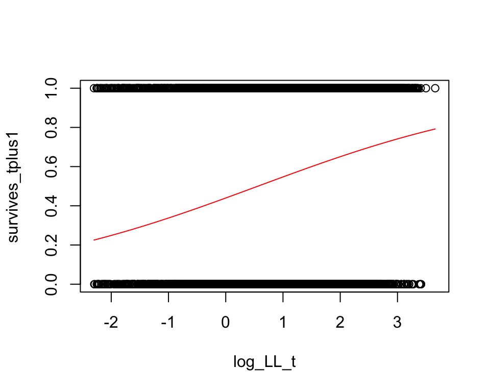

```r
 # plot model results
 plot(survives_tplus1 ~ log_LL_t, data = survDat_N)
 newdata <- data.frame("log_LL_t" = seq(from = min(survDat_N$log_LL_t, na.rm = TRUE),
                                        to = max(survDat_N$log_LL_t, na.rm = TRUE),
                                        length.out = 100),
                       "N_all" = seq(from = min(survDat_N$N_all, na.rm = TRUE),
                                     to = max(survDat_N$N_all, na.rm = TRUE),
                                     length.out = 100))
 lines(x = newdata$log_LL_t, y = predict(object = survMod_N, newdata =  newdata, type = "response"), col = "red")
```

**Growth ($G(z',z)$)**

```r
# lm w/ log-transformed size_t and size_t+1
 sizeMod_N <- lm(log_LL_tplus1 ~ log_LL_t + N_all, data = dat)
 summary(sizeMod_N)
```

```
##
## Call:
## lm(formula = log_LL_tplus1 ~ log_LL_t + N_all, data = dat)
##
## Residuals:
##      Min       1Q   Median       3Q      Max
## -2.67404 -0.32564 -0.02689  0.32407  1.53746
##
## Coefficients:
##               Estimate Std. Error t value Pr(>|t|)
## (Intercept)  1.827e+00  1.782e-02  102.54   <2e-16 ***
## log_LL_t     1.690e-01  7.138e-03   23.68   <2e-16 ***
## N_all       -6.073e-04  3.094e-05  -19.63   <2e-16 ***
## ---
## Signif. codes:  0 '***' 0.001 '**' 0.01 '*' 0.05 '.' 0.1 ' ' 1
##
## Residual standard error: 0.4839 on 3680 degrees of freedom
##   (5049 observations deleted due to missingness)
## Multiple R-squared:  0.2156, Adjusted R-squared:  0.2152
## F-statistic: 505.9 on 2 and 3680 DF,  p-value: < 2.2e-16
```

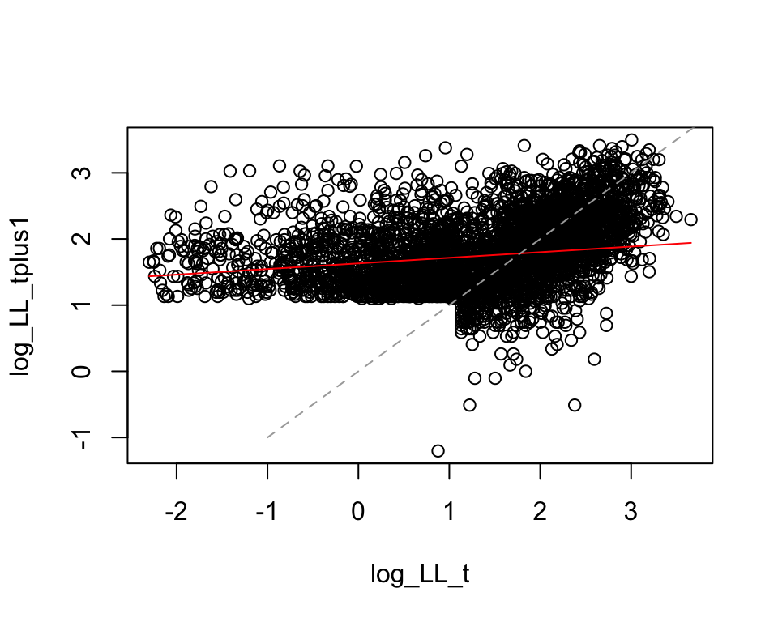

```r
 # plot model results
 plot(log_LL_tplus1 ~ log_LL_t, data = dat)
 newdata <- data.frame("log_LL_t" = seq(from = min(dat$log_LL_t, na.rm = TRUE),
                                        to = max(dat$log_LL_t, na.rm = TRUE),
                                        length.out = 100),
                       "N_all" = seq(from = min(dat$N_all, na.rm = TRUE),
                                     to = max(dat$N_all, na.rm = TRUE),
                                     length.out = 100))
 lines(x = newdata$log_LL_t, y = predict(object = sizeMod_N, newdata =  newdata), col = "red")
 lines(x = c(-1,4), y = c(-1,4), col = "darkgrey", lty = 2)
```

**Number of seeds produced, according to plant size ($b(z)$)**

```r
# using size in current year (no. of seeds/plant, for those that flowered ~ size_t)
 seedDat_N <- dat[dat$flowering == 1,]
 # fit a negative binomial glm (poisson was overdispersed)
 seedMod_N <- MASS::glm.nb(Num_seeds ~ log_LL_t, data = seedDat_N)
 summary(seedMod_N)
```

```
##
## Call:
## MASS::glm.nb(formula = Num_seeds ~ log_LL_t, data = seedDat_N,
##     init.theta = 2.018311072, link = log)
##
## Deviance Residuals:
##     Min       1Q   Median       3Q      Max
## -3.2573  -0.8830  -0.2820   0.4062   3.5908
##
## Coefficients:
##             Estimate Std. Error z value Pr(>|z|)
## (Intercept)   2.9559     0.2585   11.43   <2e-16 ***
## log_LL_t      1.3321     0.1107   12.03   <2e-16 ***
## ---
## Signif. codes:  0 '***' 0.001 '**' 0.01 '*' 0.05 '.' 0.1 ' ' 1
##
## (Dispersion parameter for Negative Binomial(2.0183) family taken to be 1)
##
##     Null deviance: 726.75  on 547  degrees of freedom
## Residual deviance: 592.19  on 546  degrees of freedom
##   (16 observations deleted due to missingness)
## AIC: 7599.7
##
## Number of Fisher Scoring iterations: 1
##
##
##               Theta:  2.018
##           Std. Err.:  0.114
##
##  2 x log-likelihood:  -7593.731
```

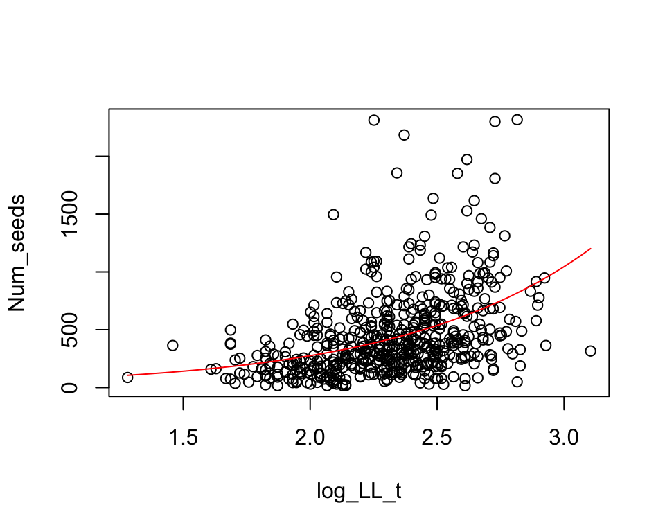

```r
 # plot model results
 plot(Num_seeds ~ log_LL_t, data = seedDat_N)
 newdata <- data.frame("log_LL_t" = seq(from = min(seedDat_N$log_LL_t, na.rm = TRUE),
                                        to = max(seedDat_N$log_LL_t, na.rm = TRUE),
                                        length.out = 100))
 lines(x = newdata$log_LL_t, y = predict(object = seedMod_N, newdata =  newdata, type = "response"), col = "red")
```

**Flowering probability ($p_b(z)$)**

```r
 # using size in current year (w/ squared term)
 # logistic glm with log-transformed size_t
 flwrMod_N <- suppressWarnings(glm(flowering ~ log_LL_t + I(log_LL_t^2) + N_all,
                                    data = dat, family = binomial))
 summary(flwrMod_N)
```

```
##
## Call:
## glm(formula = flowering ~ log_LL_t + I(log_LL_t^2) + N_all, family = binomial,
##     data = dat)
##
## Deviance Residuals:
##     Min       1Q   Median       3Q      Max
## -0.8544  -0.3593  -0.0108   0.0000   3.9931
##
## Coefficients:
##                 Estimate Std. Error z value Pr(>|z|)
## (Intercept)   -3.404e+01  2.271e+00 -14.992   <2e-16 ***
## log_LL_t       2.786e+01  1.992e+00  13.988   <2e-16 ***
## I(log_LL_t^2) -5.840e+00  4.329e-01 -13.489   <2e-16 ***
## N_all         -4.869e-04  2.139e-04  -2.276   0.0228 *
## ---
## Signif. codes:  0 '***' 0.001 '**' 0.01 '*' 0.05 '.' 0.1 ' ' 1
##
## (Dispersion parameter for binomial family taken to be 1)
##
##     Null deviance: 4180.9  on 8729  degrees of freedom
## Residual deviance: 2869.6  on 8726  degrees of freedom
##   (2 observations deleted due to missingness)
## AIC: 2877.6
##
## Number of Fisher Scoring iterations: 11
```

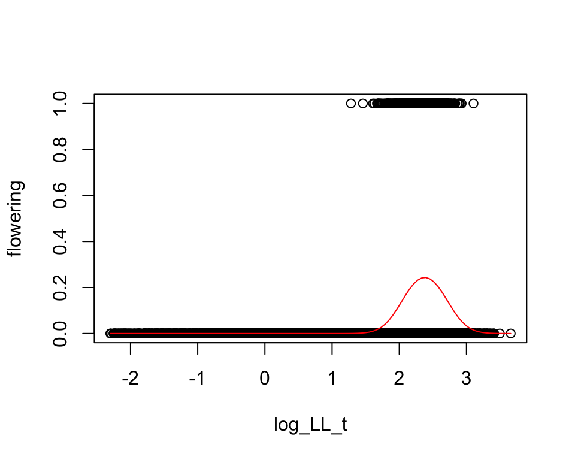

```r
 # plot model results
 plot(flowering ~ log_LL_t, data = dat)
 newdata <- data.frame("log_LL_t" = seq(from = min(dat$log_LL_t, na.rm = TRUE),
                                        to = max(dat$log_LL_t, na.rm = TRUE),
                                        length.out = 100),
                       "N_all" = seq(from = min(dat$N_all, na.rm = TRUE),
                                     to = max(dat$N_all, na.rm = TRUE),
                                     length.out = 100)
                       )
 lines(x = newdata$log_LL_t, y = predict(object = flwrMod_N, newdata =  newdata, type = "response"), col = "red")
```

**Distribution of recruit size ($c_o(z')$)**

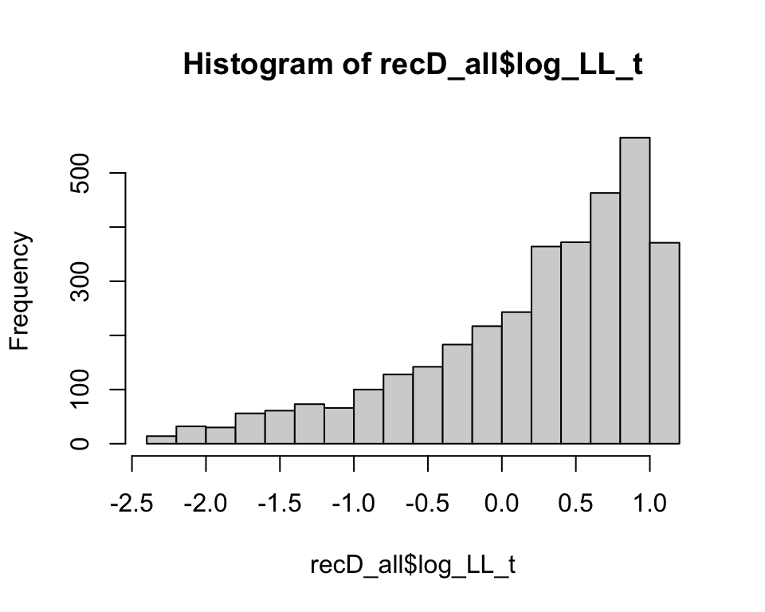

```r
 # subset the data
 recD_all <- dat[dat$seedling == 1,]

# plot the data
hist(recD_all$log_LL_t)
```

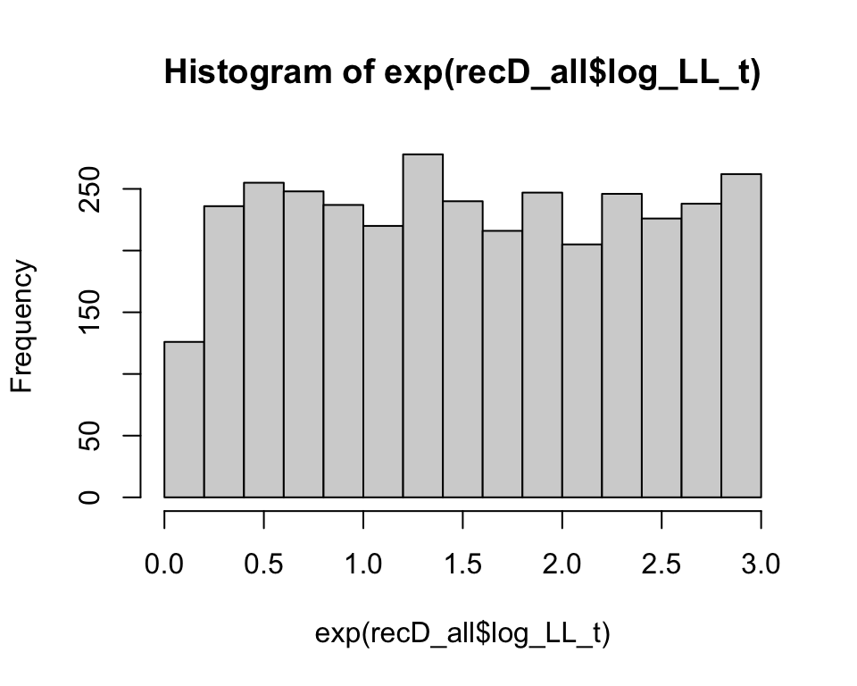

```r
# the recruit size data is no longer ~ normally distributed
# however, the data passed through the exp() function (reverse log-transform) is uniform and bounded by 0.1 and 3, so I used this as the distribution
#plot the exp() data
hist(exp(recD_all$log_LL_t))
```

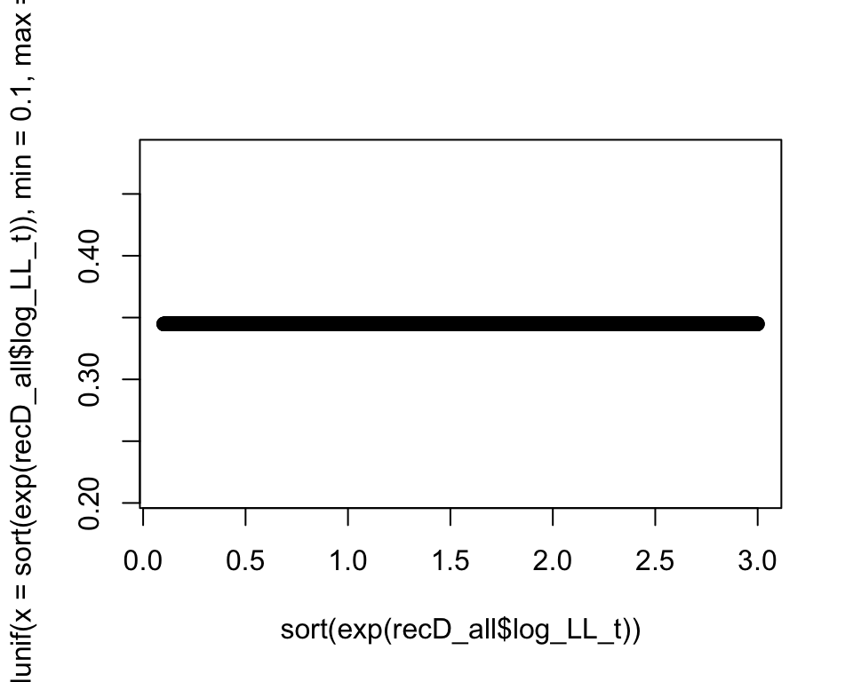

```r
# plot the exp(log_LL) unifomr dist.
plot(x = sort(exp(recD_all$log_LL_t)), y = dunif(x = sort(exp(recD_all$log_LL_t)), min = .1, max = 3))
```

**Get germination rate and rate of seed viability maintenance**

```r
## germination rate
germ.rt <- 0.203

## seed viability rate
viab.rt <- 0.585
```

**Probability that a seed from the seedbank in year t will germinate to a new continuous stage recruit in year t+1 ($outSB$)**

```r
 outSB_all <- germ.rt * .9
```

**Probability that a seed from the seedbank in year t will stay in the seedbank in year t+1 ($staySB$)**

```r
 ## Probability that a seed from the seedbank in year t will stay in the seedbank in year t+1 ($staySB$)--Burgess, 2005 shows that rate of viability doesn't really decrease much with time
 # (1 - germ.rt) * 0.9
 staySB_all<- (1-germ.rt) * .9  #estimate that 10% seeds in the SB die from year t to year t+1
```

**Probability that a seed produced by an adult plant in year t will enter the seedbank in year t+1 ($goSB$)**

```r
 goSB_all <- viab.rt * (1 - germ.rt)
```

**Probability that a seed from a plant in year t will go directly to the continuous stage ($goCont$)**

```r
 goCont_all <- viab.rt * germ.rt
```

### Implement the IPM using `ipmr`

Note: Now that I have only one discrete stage, I feel more capable of figuring out how to code the IPM by hand, so that is what I plan on ultimately doing. Hopefully the results won’t be different from the model below!

**Set up the parameter list**

```r
#### Deterministic, density-dependent IPM with CONTINOUS SEEDLINGS ####
data_list <- list(
  g_int     = coef(sizeMod_N)[1], # growth
  g_slope   = coef(sizeMod_N)[2],
  g_dd      = coef(sizeMod_N)[3],
  g_sd      = summary(sizeMod_N)$sigma,
  s_int     = coef(survMod_N)[1], # survival
  s_slope   = coef(survMod_N)[2],
  s_dd      = coef(survMod_N)[3],
  p_b_int   = coef(flwrMod_N)[1], #probability of flowering
  p_b_slope = coef(flwrMod_N)[2],
  p_b_slope_2 = coef(flwrMod_N)[3],
  p_b_dd    = coef(flwrMod_N)[4],
  b_int   = coef(seedMod_N)[1], #seed production
  b_slope = coef(seedMod_N)[2],
  outSB  = outSB_all,
  staySB = staySB_all,
  goSB   = goSB_all,
  goCont = goCont_all
)

# inital population state
init_size_state <- runif(500)

contSeedlings_IPM_dd <- init_ipm(sim_gen   = "general",
                              di_dd     = "dd",
                              det_stoch = "det") %>%
  define_kernel(
    name          = "P",
    formula       =(1-p_b.) * s. * g. * d_size,

    s.            = 1/(1 + exp(-(s_int + s_slope * size_1 + s_dd * sum(n_size_t)))),
    g.            = dnorm(size_2, g_mu., g_sd),
    g_mu.         = g_int + g_slope * size_1 + g_dd * sum(n_size_t),
    p_b.          = 1/(1 + exp(-(p_b_int + p_b_slope * size_1 + p_b_slope_2 * (size_1^2) + p_b_dd * sum(n_size_t)))),

    family        = "CC",
    data_list     = data_list,
    states        = list(c('size')),
    uses_par_sets = FALSE,
    evict_cor     = TRUE,
    evict_fun     = truncated_distributions("norm", "g.")
  ) %>%
  define_kernel(
    name          = "F",
    formula       = p_b. * b. * goCont. * c_o. * d_size,

    p_b.          = 1/(1 + exp(-(p_b_int + p_b_slope * size_1 + p_b_slope_2 * (size_1^2) + p_b_dd * sum(n_size_t)))),
    b.            = exp(b_int + b_slope * size_1),
    c_o.          = dunif(exp(size_2), min = 0.1, max = 3),
    goCont.       = goCont,

    family        = "CC",
    data_list     = data_list,
    states        = list(c('size')),
    uses_par_sets = FALSE,
    evict_cor     = TRUE,
    evict_fun     = truncated_distributions("norm", "c_o.")
  ) %>% define_kernel(
    name          = "seedbank_to_continuous",
    formula       = outSB. * c_o. * d_size,

    c_o.          = dunif(exp(size_2), min = 0.1, max = 3),
    outSB.       = outSB,

    family        = "DC",
    data_list     = data_list,
    states        = list(c('size')),
    uses_par_sets = FALSE,
    evict_cor     = TRUE,
    evict_fun     = truncated_distributions("norm", "c_o.")
  ) %>% define_kernel(
    name          = "seedbank_to_seedbank",
    formula       = staySB.,

    staySB.       = staySB,

    family        = "DD",
    data_list     = data_list,
    states        = list(c('b')),
    uses_par_sets = FALSE,
    evict_cor     = FALSE
  )   %>% define_kernel(
    name          = "continuous_to_seedbank",
    formula       = p_b. * b. * goSB. * d_size,

    p_b.          = 1/(1 + exp(-(p_b_int + p_b_slope * size_1 + p_b_slope_2 * (size_1^2) + p_b_dd * sum(n_size_t)))),
    b.            = exp(b_int + b_slope * size_1),
    goSB.       = goSB,

    family        = "CD",
    data_list     = data_list,
    states        = list(c('size', 'b')),
    uses_par_sets = FALSE,
    evict_cor     = FALSE
  )  %>%
  define_impl(
    make_impl_args_list(
      kernel_names = c("P", "F", "seedbank_to_continuous", "seedbank_to_seedbank", "continuous_to_seedbank"),
      int_rule = rep("midpoint", 5),
      state_start = c("size", "size", "b", "b", "size"),
      state_end = c("size", "size", "size", "b", "b")
    )
  ) %>%
  define_domains(
    size = c(
      min(dat$log_LL_t, na.rm = TRUE) * 1.2, # lower bound (L)
      max(dat$log_LL_t, na.rm = TRUE) * 1.2, # upper bound (U)
      500 # number of mesh points
    )
  ) %>%
  define_pop_state(
    n_size = runif(500),
    n_b = 400
  ) %>%
  make_ipm(
    iterations = 1000
  )
```

### Get the Lambda Value

```r
lambda(contSeedlings_IPM_dd)
```

```
## lambda
##      1
```

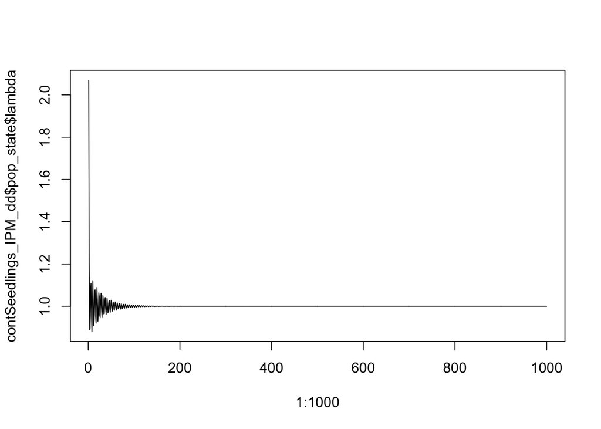

```r
plot(x = 1:1000, y = contSeedlings_IPM_dd$pop_state$lambda, type = 'l')
```

QUESTION: Does a lambda of one seem reasonable?